# Exploring the BRFSS data

## Part 1: Data

The data was collected randomly across most US territories and should be fairily well representative of non-institutionalized adults (18 years of age and older) residing in the US, with only a few caveats:

The data might suffer slightly from collection bias, as some households might not have phones to participate in the surveys, expecially low income, rural and low education households.( source : http://www.pewinternet.org/2013/06/05/smartphone-ownership-2013/ )

The data may also suffer from other biases, such as avalibilty, where some participants may not want, or be able to respond to the questionaire, introducing bias towards the types of people that would, or could do so. The data may be biased against non-english speaking, disabled, busy or disagreable households (amongst others).

Since the data is observational rather than experimental, only correlational inferences should be drawn, as it is not clear that causal relationships can be attributed to observational data.

```r
library(knitr)
library(ggplot2)
library(dplyr)
library(reshape)
library(data.table)
library(corrplot)
load("brfss2013.RData")
```

## Part 2 and 3: Research questions and Exploratory Data Analisys

**Research quesion 1: How do habits correlate to general health?**

Since the BRFSS objective is to collect data on preventive health practices and risk behaviors that are linked to chronic diseases, injuries, and preventable infectious diseases that affect the adult population, we should start by finding out what variables were collected to measure health in general, and what habits were most correlated to them.

Let’s skim trough all variables collected and take note of the ones that seem most important for our current goal:

```r
names(brfss2013)
```

```
##   [1] "X_state"   "fmonth"    "idate"     "imonth"    "iday"
##   [6] "iyear"     "dispcode"  "seqno"     "X_psu"     "ctelenum"
##  [11] "pvtresd1"  "colghous"  "stateres"  "cellfon3"  "ladult"
##  [16] "numadult"  "nummen"    "numwomen"  "genhlth"   "physhlth"
##  [21] "menthlth"  "poorhlth"  "hlthpln1"  "persdoc2"  "medcost"
##  [26] "checkup1"  "sleptim1"  "bphigh4"   "bpmeds"    "bloodcho"
##  [31] "cholchk"   "toldhi2"   "cvdinfr4"  "cvdcrhd4"  "cvdstrk3"
##  [36] "asthma3"   "asthnow"   "chcscncr"  "chcocncr"  "chccopd1"
##  [41] "havarth3"  "addepev2"  "chckidny"  "diabete3"  "veteran3"
##  [46] "marital"   "children"  "educa"     "employ1"   "income2"
##  [51] "weight2"   "height3"   "numhhol2"  "numphon2"  "cpdemo1"
##  [56] "cpdemo4"   "internet"  "renthom1"  "sex"       "pregnant"
##  [61] "qlactlm2"  "useequip"  "blind"     "decide"    "diffwalk"
##  [66] "diffdres"  "diffalon"  "smoke100"  "smokday2"  "stopsmk2"
##  [71] "lastsmk2"  "usenow3"   "alcday5"   "avedrnk2"  "drnk3ge5"
```

[output cut: 51 more lines]

To start lets take note of all the health variables and find their descriptions.

genhlth: General Health

physhlth: Number Of Days Physical Health Not Good

menthlth: Number Of Days Mental Health Not Good

poorhlth: Poor Physical Or Mental Health

X_rfhlth: Adults with good or better health

```r
brfss2013[40:70, ] %>%
  select(genhlth, physhlth, menthlth, poorhlth, X_rfhlth)
```

```
##      genhlth physhlth menthlth poorhlth              X_rfhlth
## 40      Good        0        0       NA Good or Better Health
## 41 Excellent        0        0       NA Good or Better Health
## 42      Good        0        0       NA Good or Better Health
## 43      Poor       30        0       30   Fair or Poor Health
## 44      Good        0        0       NA Good or Better Health
## 45      Fair        2       30        4   Fair or Poor Health
## 46      Good        0       NA        0 Good or Better Health
## 47      Good        4        0        0 Good or Better Health
## 48      Good        0        0       NA Good or Better Health
## 49 Excellent        0        0       NA Good or Better Health
## 50 Excellent        0        0       NA Good or Better Health
## 51      Good        0        0       NA Good or Better Health
## 52 Very good        0        0       NA Good or Better Health
## 53 Excellent        0        0       NA Good or Better Health
```

[output cut: 17 more lines]

genhlth is categorical and ordinal (from Poor to Excellent),

physhlth, menthlth, poorhlth are all numerical but a little sparse.

X_rfhlth is just a calculated variable separating genhlth into two categories.

We will be using genhlth as the main measure of health, as the other variables seem to be somewhat unreliable (can you remember exactly how many days you were sick last year?) and they should already be accounted for by the genhlth measure.

Lets factor genhlth into a separate dataset such that we can compare other variables to it

```r
health = brfss2013["genhlth"][0:nrow(brfss2013), ]
health <- ordered(x = health,
                 levels = c('Poor', 'Fair', 'Good', 'Very good', 'Excellent'))
health[0:5]
```

```
## [1] Fair      Good      Good      Very good Good
## Levels: Poor < Fair < Good < Very good < Excellent
```

Now lets find some variables related to habits:

sleptim1: How Much Time Do You Sleep

internet: Internet Use In The Past 30 Days?

X_smoker3: Everyday smoker, Someday smoker, Former smoker, Non-smoker

alcday5: Days In Past 30 Had Alcoholic Beverage

fruitju1: How Many Times Did You Drink 100 Percent Pure Fruit Juices?

fruit1: How Many Times Did You Eat Fruit?

fvbeans: How Many Times Did You Eat Beans Or Lentils?

fvgreen: How Many Times Did You Eat Dark Green Vegetables?

fvorang: How Many Times Did You Eat Orange-Colored Vegetables?

vegetab1: How Many Times Did You Eat Other Vegetables?

exerany2: Exercise In Past 30 Days

strength: How Many Times Did You Do Physical Activities Or Exercises To Strengthen Your Muscles

ssbsugar: How Often Do You Drink Regular Soda Or Pop?

ssbfrut2: How Often Did You Drink Sugar-Sweetened Drinks?

Now we can create a new dataframe consisting only of habits and proceed to clean it up and factor it for correlation analysis.

```r
habits <- brfss2013 %>% select('sleptim1', 'internet', 'X_smoker3', 'fruitju1', 'fruit1',
                    'fvbeans', 'fvgreen', 'fvorang', 'vegetab1', 'exerany2',
                                'strength', 'ssbsugar', 'ssbfrut2')

habits[50:60, ]
```

```
##    sleptim1 internet                             X_smoker3 fruitju1 fruit1
## 50        7      Yes                         Former smoker        0    304
## 51        9      Yes                          Never smoked      204    203
## 52        7      Yes                         Former smoker        0    310
## 53        6       No                          Never smoked      101    320
## 54        7      Yes                         Former smoker       NA     NA
## 55        8      Yes                          Never smoked      201    202
## 56        4      Yes                         Former smoker        0    308
## 57        8       No Current smoker - now smokes every day      201    101
## 58        6      Yes                          Never smoked      301    320
## 59        6      Yes                          Never smoked      310    305
## 60        7      Yes                          Never smoked      304    101
##    fvbeans fvgreen fvorang vegetab1 exerany2 strength ssbsugar ssbfrut2
## 50     312     305       0      310      Yes        0       NA       NA
## 51     304     304     205      101      Yes        0       NA       NA
## 52       0     102       0      203      Yes        0       NA       NA
## 53     320     315     302      325     <NA>       NA       NA       NA
## 54      NA      NA      NA       NA     <NA>       NA       NA       NA
## 55     202     201     301      202       No        0       NA       NA
## 56     303     320     306      325       No      220       NA       NA
## 57     203     203     201      102      Yes        0       NA       NA
## 58     304     310     320      330       No        0       NA       NA
## 59     303     320     305      320       No      230       NA       NA
## 60     305     203     305      205      Yes      102       NA       NA
```

```r
habits$internet <- as.numeric(ordered(habits[0:nrow(habits), 'internet'],
                                      levels = c("No", "Yes"),
                                      labels = c("No", "Yes")))

habits$X_smoker3 <- as.numeric(ordered(habits[0:nrow(habits), 'X_smoker3'],
                               levels = c("Never smoked",
                                          "Former smoker",
                                          "Current smoker - now smokes some days",
                                          "Current smoker - now smokes every day"),
                                labels = c("Never smoked",
                                          "Former smoker",
                                          "Current smoker - now smokes some days",
                                          "Current smoker - now smokes every day")))

habits$exerany2 <- as.numeric(ordered(habits[0:nrow(habits), 'exerany2'],
                                      levels = c("No", "Yes"),
                                      labels = c("No", "Yes")))

habits[50:60, ]
```

```
##    sleptim1 internet X_smoker3 fruitju1 fruit1 fvbeans fvgreen fvorang
## 50        7        2         2        0    304     312     305       0
## 51        9        2         1      204    203     304     304     205
## 52        7        2         2        0    310       0     102       0
## 53        6        1         1      101    320     320     315     302
## 54        7        2         2       NA     NA      NA      NA      NA
## 55        8        2         1      201    202     202     201     301
## 56        4        2         2        0    308     303     320     306
## 57        8        1         4      201    101     203     203     201
## 58        6        2         1      301    320     304     310     320
## 59        6        2         1      310    305     303     320     305
## 60        7        2         1      304    101     305     203     305
##    vegetab1 exerany2 strength ssbsugar ssbfrut2
## 50      310        2        0       NA       NA
## 51      101        2        0       NA       NA
## 52      203        2        0       NA       NA
## 53      325       NA       NA       NA       NA
## 54       NA       NA       NA       NA       NA
## 55      202        1        0       NA       NA
## 56      325        1      220       NA       NA
## 57      102        2        0       NA       NA
## 58      330        1        0       NA       NA
## 59      320        1      230       NA       NA
## 60      205        2      102       NA       NA
```

Now to find the correlations.

```r
correlations = cor(x = habits, y = as.numeric(health), use = "complete.obs")
correlations
```

```
##                   [,1]
## sleptim1   0.077256354
## internet   0.290887562
## X_smoker3 -0.174437216
## fruitju1   0.045995304
## fruit1    -0.053958275
## fvbeans    0.040770989
## fvgreen    0.005717422
## fvorang    0.037724510
## vegetab1  -0.051830618
## exerany2   0.263101187
## strength   0.183177156
## ssbsugar  -0.002275287
## ssbfrut2   0.024706676
```

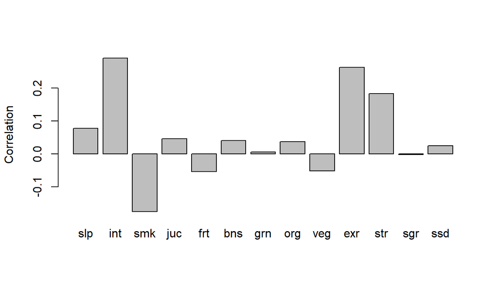

```r
barplot(correlations[,], ylab = "Correlation", names.arg = c('slp', 'int', 'smk', 'juc', 'frt',
                    'bns', 'grn', 'org', 'veg', 'exr',
                                'str', 'sgr', 'ssd'))
```

As expected, smoking has a drastic negative correlation with general health.

Surprisingly, the correlation that any type of exercising has with health is very high, compared to eating ‘healthy’ foods which have much smaller correlations to health.

Unexpectedly Internet usage has an even bigger correlation to health than other habits, even greater than exercising (I thought it would go the other way)!

**Research quesion 2: Why is internet usage so highly correlated to general health?**

Lets begin by finding out what kinds of populations are more likely to be internet users.

First we separate internet users into a dataframe.

```r
internet = brfss2013["internet"][0:nrow(brfss2013), ]
internet <- ordered(x = internet,
                 levels = c('No', 'Yes'),
                 labels = c('No', 'Yes'))
```

Now we find some variables related to population variances:

pvtresd2: Do You Live In A Private Residence?

hlthpln1: Have Any Health Care Coverage

veteran3: Are You A Veteran

children: Number Of Children In Household

educa: Education Level

X_incomg: Income Level

sex: Respondents Sex

X_age_g: Reported Age in Six Groups

We also need to factor the data for correlational analisys.

```r
population <- brfss2013 %>% select('pvtresd2', 'hlthpln1', 'veteran3',
                    'children', 'educa', 'X_incomg', 'sex', 'X_age_g')

population[50:60, ]
```

```
##    pvtresd2 hlthpln1 veteran3 children
## 50      Yes      Yes      Yes        0
## 51      Yes      Yes       No        0
## 52      Yes      Yes       No        0
## 53      Yes      Yes       No        0
## 54      Yes      Yes       No        0
## 55      Yes      Yes       No        1
## 56      Yes       No       No        0
## 57      Yes      Yes       No        0
## 58      Yes      Yes       No        2
## 59      Yes      Yes       No        4
## 60      Yes      Yes      Yes        2
##                                                           educa
## 50                   College 4 years or more (College graduate)
## 51 College 1 year to 3 years (Some college or technical school)
```

[output cut: 21 more lines]

```r
population$pvtresd2 <- as.numeric(ordered(population[0:nrow(population), 'pvtresd2'],
                                      levels = c("No", "Yes"),
                                      labels = c("No", "Yes")))

population$hlthpln1 <- as.numeric(ordered(population[0:nrow(population), 'hlthpln1'],
                                      levels = c("No", "Yes"),
                                      labels = c("No", "Yes")))

population$veteran3 <- as.numeric(ordered(population[0:nrow(population), 'veteran3'],
                                      levels = c("No", "Yes"),
                                      labels = c("No", "Yes")))

population$educa <- as.numeric(ordered(population[0:nrow(population), 'educa'],
                                      levels = c("Never attended school or only kindergarten",
                                                 "Grades 1 through 8 (Elementary)",
                                                 "Grades 9 through 11 (Some high school)",
                                                 "Grade 12 or GED (High school graduate)",
                                                 "College 1 year to 3 years (Some college",
                                                 "College 4 years or more (College graduate)"),
                                      labels = c("Never attended school or only kindergarten",
                                                 "Grades 1 through 8 (Elementary)",
                                                 "Grades 9 through 11 (Some high school)",
                                                 "Grade 12 or GED (High school graduate)",
                                                 "College 1 year to 3 years (Some college",
                                                 "College 4 years or more (College graduate)")))

population$X_incomg <- as.numeric(ordered(population[0:nrow(population), 'X_incomg'],
                                      levels = c("Less than $15,000",
                                                 "$15,000 to less than $25,000",
                                                 "$25,000 to less than $35,000",
                                                 "$35,000 to less than $50,000",
                                                 "$50,000 or more"),
                                      labels = c("Less than $15,000",
                                                 "$15,000 to less than $25,000",
                                                 "$25,000 to less than $35,000",
                                                 "$35,000 to less than $50,000",
                                                 "$50,000 or more")))

population$sex <- as.numeric(ordered(population[0:nrow(population), 'sex'],
                                      levels = c("Male", "Female"),
                                      labels = c("Male", "Female")))

population$X_age_g <- as.numeric(ordered(population[0:nrow(population), 'X_age_g'],
                                      levels = c("Age 18 to 24",
                                                 "Age 25 to 34",
                                                 "Age 35 to 44",
                                                 "Age 45 to 54",
                                                 "Age 55 to 64",
                                                 "Age 65 or older"),
                                      labels = c("Age 18 to 24",
                                                 "Age 25 to 34",
                                                 "Age 35 to 44",
                                                 "Age 45 to 54",
                                                 "Age 55 to 64",
                                                 "Age 65 or older")))


population[50:60, ]
```

```
##    pvtresd2 hlthpln1 veteran3 children educa X_incomg sex X_age_g
## 50        2        2        2        0     6        5   1       4
## 51        2        2        1        0    NA       NA   2       6
## 52        2        2        1        0    NA        5   2       5
## 53        2        2        1        0     6        5   1       5
## 54        2        2        1        0     4        5   1       2
## 55        2        2        1        1     6        5   2       3
## 56        2        1        1        0     4        1   2       4
## 57        2        2        1        0    NA        4   1       4
## 58        2        2        1        2     4        4   1       3
## 59        2        2        1        4    NA        5   1       3
## 60        2        2        2        2     6        5   1       4
```

Now to find out how they correlate to internet usage

```r
correlations_internet = cor(x = population, y = as.numeric(internet), use = "complete.obs")
correlations_internet
```

```
##                 [,1]
## pvtresd2 -0.02028250
## hlthpln1  0.12941696
## veteran3 -0.03855981
## children  0.04827164
## educa     0.41166541
## X_incomg  0.37088021
## sex       0.04388050
## X_age_g  -0.26182693
```

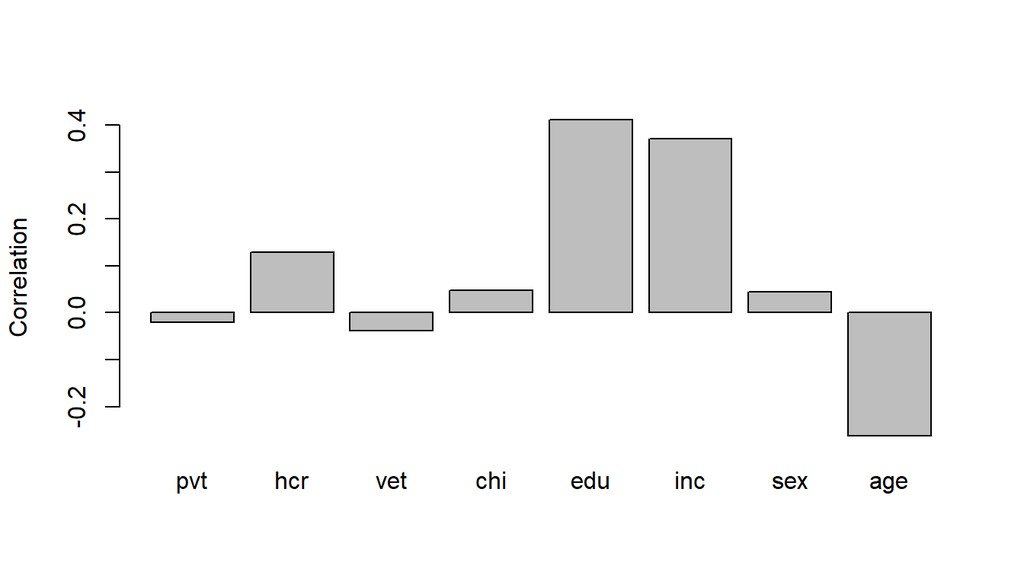

```r
barplot(correlations_internet[,], ylab = "Correlation", names.arg = c('pvt', 'hcr', 'vet', 'chi', 'edu',
                    'inc', 'sex', 'age'))
```

Internet usage is extremely correlated with education and income, while being negatively correlated with age.

Lets see how these populations affect health.

**Research quesion 3:How are populations related to general health? And which is are more impactfull? Population differences or habits?**

Lets begin by mixing all the worked data into a single dataframe

```r
data <- cbind(as.numeric(health), habits)

data <- cbind(data, population)

data[70:80, ]
```

```
##    as.numeric(health) sleptim1 internet X_smoker3 fruitju1 fruit1 fvbeans
## 70                  1        2        2         4        0    305       0
## 71                  3        8        2         1      303    204       0
## 72                  5        8        1         2        0    320     315
## 73                  1        6        2         2        0    101     204
## 74                  4        7        2         2        0    330     320
## 75                  1       10        2         2        0    315     201
## 76                  2        7        2         2        0    203     205
## 77                  4        6        2         1        0    202       0
## 78                  4        7        2         1        0    205     202
## 79                  5        5        2         1      204    206     306
## 80                  4        7        2         2        0    102     312
##    fvgreen fvorang vegetab1 exerany2 strength ssbsugar ssbfrut2 pvtresd2
## 70       0     310        0       NA       NA       NA       NA       NA
## 71     330      NA       NA       NA       NA       NA       NA        2
```

[output cut: 21 more lines]

Now lets take a look at the correlation matrix of all variables (removing small correlations for visual clarity)

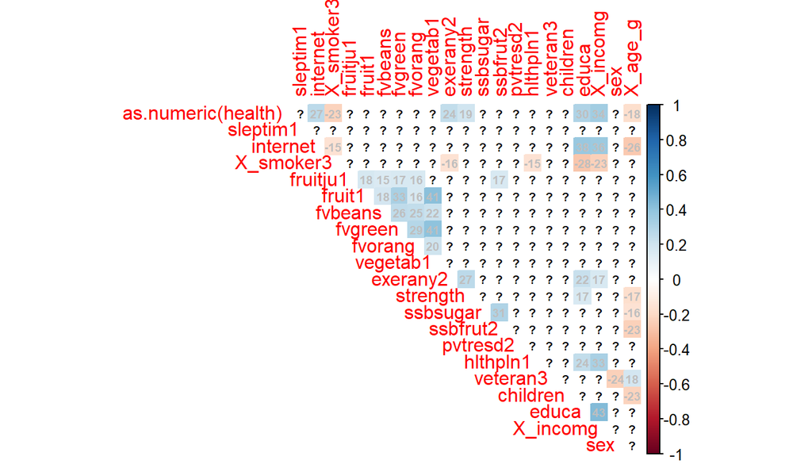

```r
data <- cor(data, use = "complete.obs")

data[abs(data) < 0.15] <- NA
corrplot(data, method = "color", addCoef.col="grey",  addCoefasPercent = TRUE, number.cex = 0.6, type = "upper", diag = FALSE)
```

It seems that health is extremely correlated to education and to income, while beeing negatively correlated to age.

There is a cluster of correlations between people who eat “healthy” foods, but without much correlation to general health.

High income and education are very correlated, and they are both correlated to exercising, internet usage, not smoking, having a health plan and having good health.

Conclusion: It seems that there is a bigger correlation between certain populations and health (mostly income and education) than habits and health, altough the correlation between health, exercise and internet usage should not be overlooked.